# Exercises: Networks

Berry Brosi

August 2024

# Preamble

These exercises can be run in either .Rmarkdown or .R. The key thing is to copy the code chunks (grey boxes with `monospaced font`) and paste them into your new file. If you’re used to working in .Rmarkdown, great! But that isn’t necessary.

**If you’re still new to R**, probably the easiest approach is:

- in RStudio, go to File > New File > R Script
- this will open a new window in your Rstudio environment, that expects only code (or comments prefaced with `#`)
- paste *only* the code from the code chunks (grey boxes with `monospaced font`)—don’t include any of the text from outside of the code chunks
- to run code line-by-line, highlight the code you want to run and then click on the “Run” button at the top right of the window with your code, and select “Run Selected Line(s)”
- alternatively, you can highlight the code and then use a keyboard shortcut:
  - Windows: control + Enter
  - Mac: command + return

As always, don’t be afraid to ask for help!

# Packages

Make sure to load these packages!

```r
library(tidyverse)
library(kableExtra)
library(bipartite)
```

# Exercise 2: edge List to bipartite

Let’s practice turning an edge list into a bipartite network; this time we will do it at a (slightly) larger scale. We are going to use data collected by Berry’s Community Ecology class at the University of Washington in spring 2022, at the UW Medicinal Plant Garden (just outside the Life Sciences Building, where the Brosi Lab is based). The data for pollinators were collected at the family level.

Click (for PC) or right-click (for Mac) [HERE](https://models4data2theory.github.io/courses_data/Networks/medgarden.csv) to download the `medgarden.csv` data file.

Import the data and alter the code below—from the website—as needed to generate a bipartite network. Call the resulting dataframe **`bipartite.med`** (as in the code below)

You can import the data into R however you like, but the code below uses a method that is straightforward for those of you that are less familiar with R: `file.choose()` which, when you run it, will generate a pop-up window asking you to select the `medgarden.csv` file from wherever you downloaded it.

```r
weighted <- read.csv(file.choose()) # pop-up window to select `medgarden.csv`

bipart.med <- weighted %>%
  group_by(plant, pollinator) %>%
  tally() %>%
  pivot_wider(id_cols = c("plant"), # plants are the rows
              names_from = pollinator, # names of new columns: unique pollinators
              values_from = n, # values in the matrix from tallied interactions
              values_fill = 0) # if no value, enter zero (otherwise NA)
```

You should get this bipartite network back (e.g., enter `View(bipartite.med)` in the RStudio console):

| plant | Osmia | Bombus | Syrphid | Halictid | Muscid | Ant | Hummingbird |
| --- | --- | --- | --- | --- | --- | --- | --- |
| Borago officinalis | 1 | 0 | 0 | 0 | 0 | 0 | 0 |
| Camassia leichtlinii | 0 | 1 | 2 | 0 | 0 | 0 | 0 |
| Catharanthus roseus | 0 | 0 | 1 | 0 | 0 | 0 | 0 |
| Coclearia afficinalis | 0 | 0 | 1 | 1 | 1 | 0 | 0 |
| Eriogonum umbellatum | 0 | 0 | 2 | 0 | 0 | 0 | 0 |
| Erysimum asperum | 0 | 0 | 4 | 1 | 0 | 2 | 0 |
| Gilia capitata | 1 | 0 | 1 | 0 | 0 | 0 | 0 |
| Glaucium flavum | 0 | 1 | 0 | 0 | 0 | 0 | 0 |
| Helleborus orientalis | 0 | 0 | 0 | 0 | 1 | 0 | 0 |
| Heuchera micrantha | 0 | 0 | 0 | 1 | 1 | 0 | 0 |
| Heuchera sanguinea | 1 | 0 | 0 | 0 | 0 | 0 | 0 |
| Horminum pyrenaicum | 0 | 0 | 3 | 0 | 0 | 0 | 0 |
| Hydrophyllum virginiana | 0 | 0 | 4 | 0 | 1 | 0 | 0 |
| Iris douglasiana | 0 | 0 | 0 | 0 | 1 | 0 | 0 |
| Polemonium reptans | 3 | 0 | 0 | 0 | 2 | 0 | 0 |
| Polygonum bisorta | 0 | 0 | 0 | 3 | 1 | 0 | 0 |
| Rhodiola rosea | 0 | 0 | 0 | 0 | 1 | 0 | 0 |
| Ruta graveolens | 0 | 0 | 0 | 2 | 0 | 0 | 0 |
| Sedua spathulifolium | 1 | 0 | 1 | 0 | 0 | 0 | 0 |
| Smilacina stellata | 0 | 0 | 0 | 0 | 1 | 0 | 0 |
| Thymus leucospermus | 1 | 0 | 1 | 2 | 0 | 0 | 0 |
| Tragopogon porrifolius | 0 | 0 | 0 | 0 | 0 | 0 | 1 |
| Wyethia angustifolia | 1 | 6 | 2 | 0 | 0 | 0 | 0 |

### Optional bonus 2.1 *(Rmarkdown only)*

If you are working in .Rmarkdown and want to produce a nicely-formatted table, here is some code to do that. You’ll want to make sure you loaded the `kable_extra` package in the “packages” section above.

```r
# show in nicely-formatted table:
kable(bipart.med, row.names = F, ) %>% kable_styling(full_width = F,
  position = "left", bootstrap_options = "condensed")
```

### Optional bonus 2.2

Import an edge list of your own data and convert it to a bipartite matrix.

# Exercise 3: plotting with visweb

Using the “medgarden” data you put into matrix form (now called `bipart.med`):

- plot via `visweb`:
  - with `type = "none"`
  - with `type = "nested"`
  - with `type = "diagonal"`

Before you do this, you will need to *slightly* change the `bipart.med` dataframe to follow the format that the `bipartite` package expects: a matrix (not a dataframe), with the plant names as row names. In doing so, we have to also remember that matrices in R cannot have non-numeric values, so we will have to also delete the “plant” column:

```r
# save plant names
plant = bipart.med$plant
# remove plant column
bipart.med = bipart.med[,-1]
# convert to matrix
bipart.med = as.matrix(bipart.med)
# add plants to row names
row.names(bipart.med) = plant
# remove `plant` variable (just to keep workspace clean)
rm(plant)
```

If you want to see if that worked, enter `View(bipart.med)` in the console.

To plot via `visweb()`, here is one example:

```r
visweb(bipart.med, type = "none")
```

You’ll have to copy and then alter that line of code to do all of the plotting variants (`none`, `nested`, and `diagonal`) specified above.

**After you have plotted with `type = "diagonal"`:** the `diagonal` method is set up to show modularity in the network. How many modules do you see in the “medgarden” network? Can you comment on the modules qualitatively in terms of the organisms involved?

### Optional bonus 3.1

Order the rows and columns of the `bipart.med` matrix by degree using the code below (or your own variant if you prefer)

```r
rows = rowSums(bipart.med > 0) # calculate plant degree
cols = colSums(bipart.med > 0) # calculate pollinator degree
roworder = order(rows, decreasing = T) # order plants by degree
colorder = order(cols, decreasing = T) # order pollinators by degree
bipart.med = bipart.med[roworder,colorder] # re-order rows and cols in matrix
```

Re-plot with `type = "none"` (the newly packed data should closely resemble the `type = "nested"` network).

### Optional bonus 3.2

Play around with visualizing some of the other datasets included in bipartite, for example the `Safariland` or `Memmott1999` datasets. To access those datasets, use `data(Safariland)` or `data(memmott1999)`

# Exercise 8: network metrics

Here is an example of how to have R (via the `bipartite` package) calculate a network metric for you, using the `networklevel()` function:

```r
networklevel(bipart.med, index = "NODF")
```

Use the `bipart.med` data you have been using so far to calculate:

- $H_2'$ (network-level specialization); in `networklevel`, use `index = "H2"`
- connectance

### Optional bonus 8.1

calculate multiple metrics for the `bipart.med` data and/or other datasets included in the `bipartite` package (see the “Optional bonus” of the previous problem). To calculate multiple metrics at once, alter this basic setup: `index = c("H2", "connectance")`

# Exercise 10: graphical null model

Analyze NODF for the “Safariland” dataset using the `r2dtable` null model graphically, using the code below:

```r
data(Safariland)
Iobs <- networklevel(Safariland, index = "NODF")[[1]]
nulls <- nullmodel(web=Safariland, N = 999, method = 'r2dtable') # can take a while...
Inulls <- sapply(nulls, function(x) nestednodf(x)$statistic[3])
plot(density(Inulls), xlim = c(0, 100), lwd = 2, main = "NODF")
# plot(hist(Inulls), xlim=c(0, 100), lwd=2, main="NODF") # histogram
abline(v=Iobs, col="red", lwd=2)
```

You should get back a graph that looks like this:

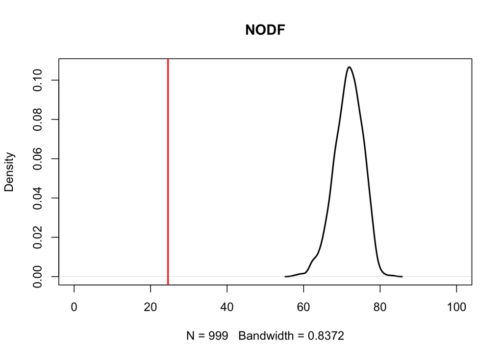

Calculate the (two-tailed) $p$-value for the above null model analysis, using the code below:

```r
# two-tailed p-value for permutation test with null models
pval = (min(length(which(Inulls>Iobs)), length(which(Iobs>Inulls))+1) /
          length(c(Iobs,Inulls)))*2
pval
```

Despite the element of randomness to the null models, which in many situations causes the $p$-value to vary slightly from person to person or run to run, given how extreme the value is here, it should be exactly 0.002.

**how do you interpret your result?** think about whether your result is statistically significant as well as the *directionality* of the result.

### Optional bonus 10.1

Re-run the analysis above with the `swap.web` null model (this is a very straightforward replacement of `r2dtable` with `swap.web`) above.

### Optional bonus 10.2

Using our discussion of the correlation among network metrics, as well as our descriptions of the null models, offer an interpretation as to *why* the two null models (`r2dtable` and `swap.web`) yield qualitatively different results.

### Optional bonus 10.3

Try one of the null models implemented in `vegan`, in particular `quasiswap_count`. Here is some code that should help you; the syntax is different for the `vegan` implementation relative to `bipartite` and in addition `vegan` returns the null models not as a list, but instead as a 3-dimensional array. The latter means you need to take a slightly different approach when calculating NODF (or any other metric) across the null models.

```r
# alternative: use vegan::nullmodel rather than bipartite
library(vegan)
# require first setting up a null model, then separately simulating it
n.vegan <- vegan::nullmodel(Safariland, "quasiswap_count") #setup
nulls.vegan <- simulate(n.vegan, nsim = 999) #simulation
# the vegan `simulate` method returns a 3-dimensional numeric array
# so need to modify the code used for the bipartite nulls
# use `apply` rather than `sapply` with MARGIN = 3
Inulls.vegan <- apply(nulls.vegan, MARGIN = 3,
                      FUN = function(x) nestednodf(x)$statistic[3])
```

You should get again a qualitatively different result relative to `swap.web`. This is somewhat curious as the two methods are supposed to be very similar… (we are not sure why!)